# Steven Mayher: Lab 05 for 431

Steven Mayher

2021-10-21

# Part A. County Health Rankings (Questions 1-6)

```r
library(tidyverse)
library(naniar)
library(broom)
library(knitr)
library(patchwork)
library(magrittr)
library(Epi)
library(dplyr)
library(janitor)
library(Epi)

source("C:/Users/smmay/OneDrive/Education/College/Coursework/CWRU/PQHS 431 - Statistical Methods I/431-data/Love-boost.R")
```

```r
lab05_data = read.csv("data/lab05_counties.csv")

midwest05 <- lab05_data %>%
  filter(state == "OH" | state == "IN" | state == "IL" | state == "MI" | state == "WI") %>%
  select(c(metro, access_to_exercise_opportunities, state, county_name))

midwest05 %>%
  miss_var_summary()
```

```
# A tibble: 4 x 3
  variable                         n_miss pct_miss
  <chr>                             <int>    <dbl>
1 metro                                 0        0
2 access_to_exercise_opportunities      0        0
3 state                                 0        0
4 county_name                           0        0
```

## Question 1 (10 points)

```r
midwest05 = midwest05 %>%
  mutate(metro_status = case_when(
    metro == 0 ~ "Rural",
    metro == 1 ~ "Metropolitan"))

midwest05 = midwest05 %>%
  rename(exercise_opportunity_access = access_to_exercise_opportunities) %>%
  mutate(exercise_opportunity_access = 100*exercise_opportunity_access)

midwest05 %>% head(., 10) # head() function used to demonstrate the first 10 rows of my midwest05 tibble
```

```
   metro exercise_opportunity_access state      county_name metro_status
1      0                       81.89    IL     Adams County        Rural
2      1                       58.35    IL Alexander County Metropolitan
3      1                       62.72    IL      Bond County Metropolitan
4      1                       88.84    IL     Boone County Metropolitan
5      0                       75.70    IL     Brown County        Rural
6      0                       77.80    IL    Bureau County        Rural
7      1                       30.24    IL   Calhoun County Metropolitan
8      0                       71.37    IL   Carroll County        Rural
9      0                       60.18    IL      Cass County        Rural
10     1                       84.22    IL Champaign County Metropolitan
```

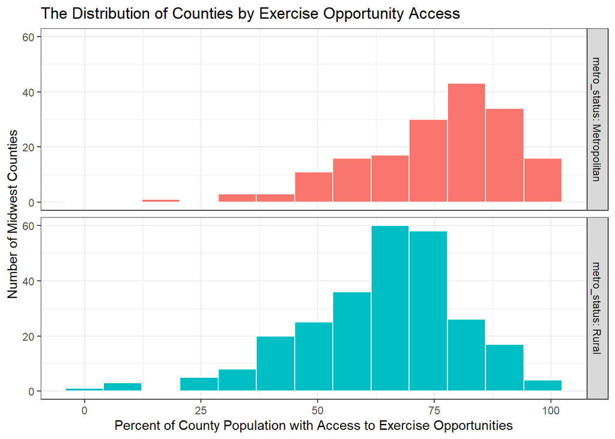

```r
midwest05 %>% ggplot(data = ., aes(x = exercise_opportunity_access, fill = factor(metro_status))) +
  geom_histogram(bins = nclass.scott(na.omit(midwest05$exercise_opportunity_access)), col = "white") +
  facet_grid(metro_status ~ ., labeller = "label_both") +
  guides(fill = "none") +
  theme_bw() +
  labs(title = "The Distribution of Counties by Exercise Opportunity Access", x = "Percent of County Population with Access to Exercise Opportunities", y = "Number of Midwest Counties")
```

Based on the histograms shown above, I would conclude that people living in metropolitan counties have on average greater access to exercise opportunities than people living in rural counties.

## Question 2 (10 points)

If we are to assume that the population of interest is the United States as a whole, then no, our sampling would not represent a true random sampling, as the states that were selected were chosen because they were a part of the Midwest. If we assume that the the population of interest is the Midwest, it still wouldn’t qualify as a random sample, as all of the counties were selected by state, and not at random from within the region itself. There really isn’t a reasonable argument for generalizing the results to the population of all counties in the US either, as again since the counties are all from five specific Midwest states, factors that affect this region of the country could impact the results in a way not found in other regions of the country (weather, for example), however it’s impossible to know this for certain without clarifying what “access to exercise opportunities” actually accounts for.

## Question 3 (5 points)

The data examined in Question 1 are independent samples. We know this because there is no pairing or matching of individual observations across exposure groups, which is indicative of an independent samples study. For further clarification, each county sample only has one measurement for `metro_status`, and the data has been broken up into two separate groups for analysis based off of this, meaning no county is ever sampled twice, which again indicates that this is an independent sample data set.

## Question 4 (15 points)

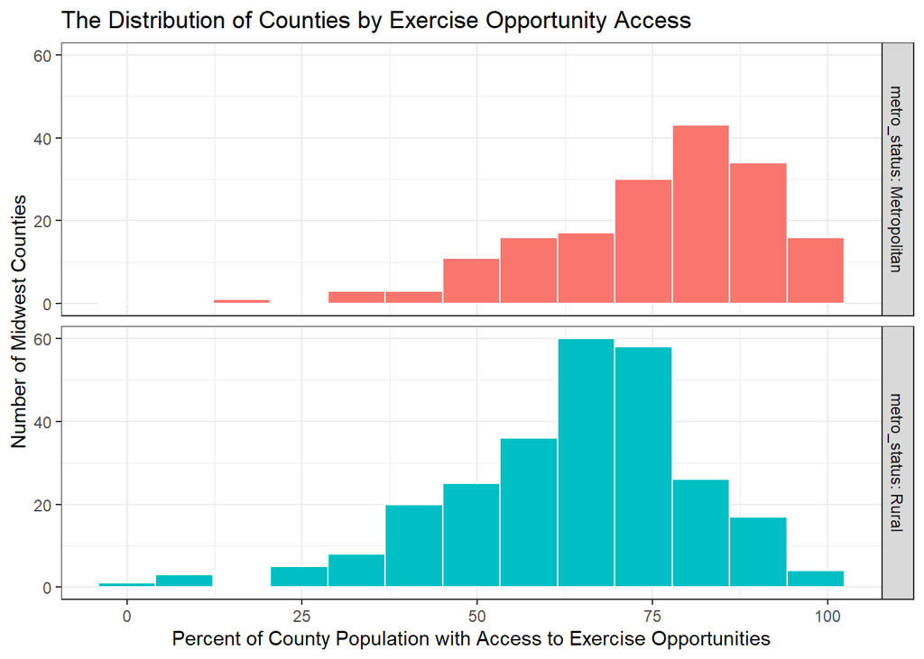

```r
midwest05_metro = midwest05 %>%
  filter(metro == "1")

midwest05_rural = midwest05 %>%
  filter(metro == "0")

midwest05 %>% ggplot(data = ., aes(x = exercise_opportunity_access, fill = factor(metro_status))) +
  geom_histogram(bins = nclass.scott(na.omit(midwest05$exercise_opportunity_access)), col = "white") +
  facet_grid(metro_status ~ ., labeller = "label_both") +
  guides(fill = "none") +
  theme_bw() +
  labs(title = "The Distribution of Counties by Exercise Opportunity Access", x = "Percent of County Population with Access to Exercise Opportunities", y = "Number of Midwest Counties")
```

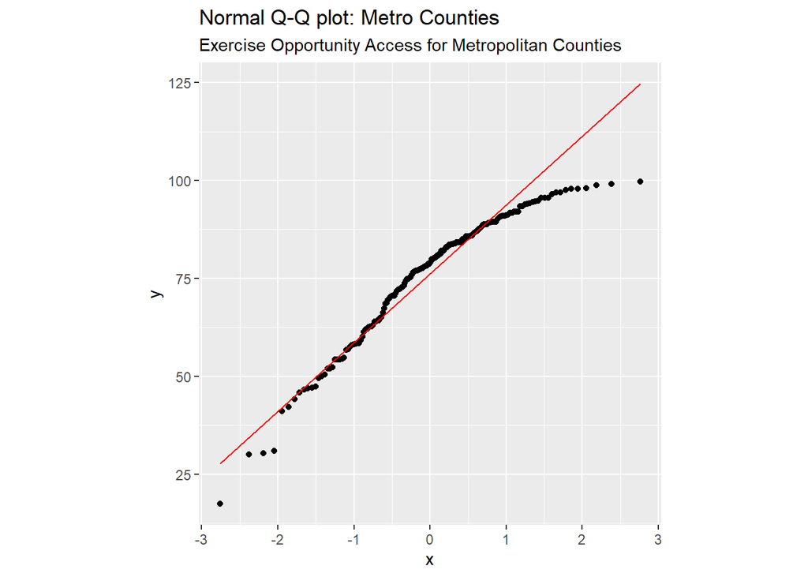

```r
ggplot(midwest05_metro, aes(sample = exercise_opportunity_access)) +
  geom_qq() +
  geom_qq_line(col = "red") +
  theme(aspect.ratio = 1) +
  labs(title = "Normal Q-Q plot: Metro Counties", subtitle = "Exercise Opportunity Access for Metropolitan Counties")
```

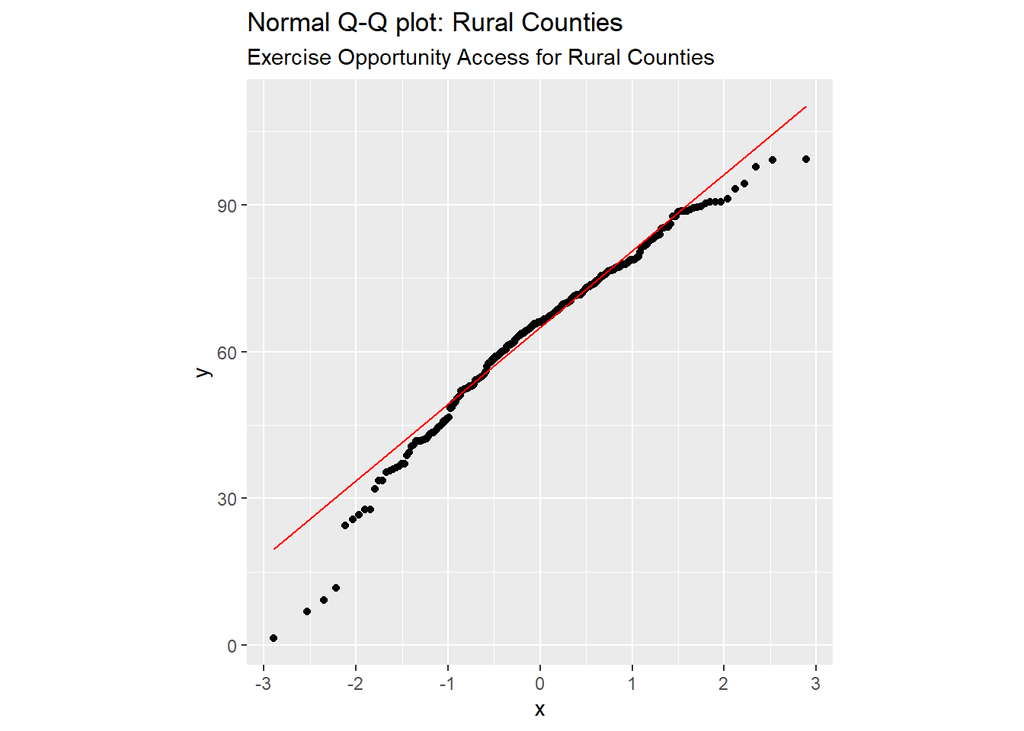

```r
ggplot(midwest05_rural, aes(sample = exercise_opportunity_access)) +
  geom_qq() +
  geom_qq_line(col = "red") +
  theme(aspect.ratio = 1) +
  labs(title = "Normal Q-Q plot: Rural Counties", subtitle = "Exercise Opportunity Access for Rural Counties")
```